# Treatment plant locations: figures for review

Verified corrections, location sources, and the multi-source pipeline

Published

November 9, 2026

Data: master layer **CWNS_Locations_20261014** (17,874 treatment plants, 3,068 verified), and the multi-source pipeline output (17,874 plants). A verified correction is a treatment plant with `Verified = "Yes"`, `Original_Correct = "No"` and a corrected point; its distance is the great-circle distance from the reported CWNS point to the corrected point.

## Headline numbers

|  | Slide 11 | Now |
| --- | --- | --- |
| Verified corrections | 316 | **841** |
| Median correction distance | 0.80 mi | **0.35 mi** |
| Mean correction distance | 3.14 mi | **1.52 mi** |
| Corrections of 10 mi or more | 20 | **21** |
| Verified plants whose reported location was wrong | ~40% | **27%** (841 of 3,068) |

Also: 40% of corrections moved half a mile or more, 22% a mile or more, 5% five miles or more; the largest is 207 mi. The mean without the corrections of 10 mi or more is 0.80 mi.

**Why the numbers fell.** 451 of the corrections are model proposals a reviewer confirmed. The model searches near the reported point, so these are short: median 0.20 mi, longest 3.9 mi. The 295 reviewer-placed corrections still look like slide 11: median 0.81 mi, mean 3.26 mi. Reviewed plants were prioritised, not sampled at random, so neither the old ~40% nor the new 27% is a national error rate.

## Verified corrections

### Fig 1. Correction distances (slide 11)

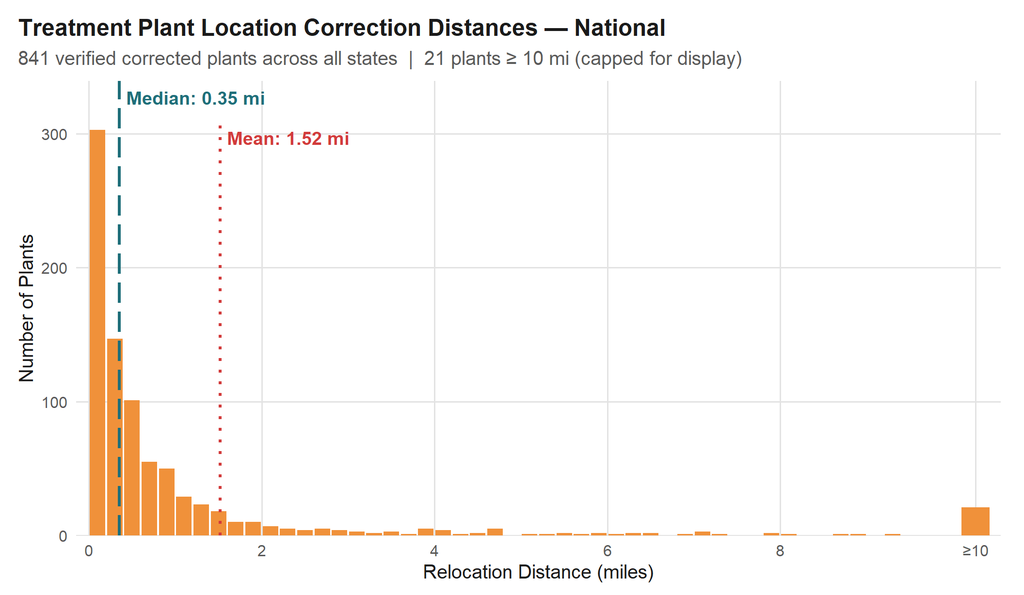

Drop-in replacement for the chart on slide 11. Bars are 0.2 mi wide; corrections of 10 mi or more are pooled in the last bar.

### Fig 2. Distance bands

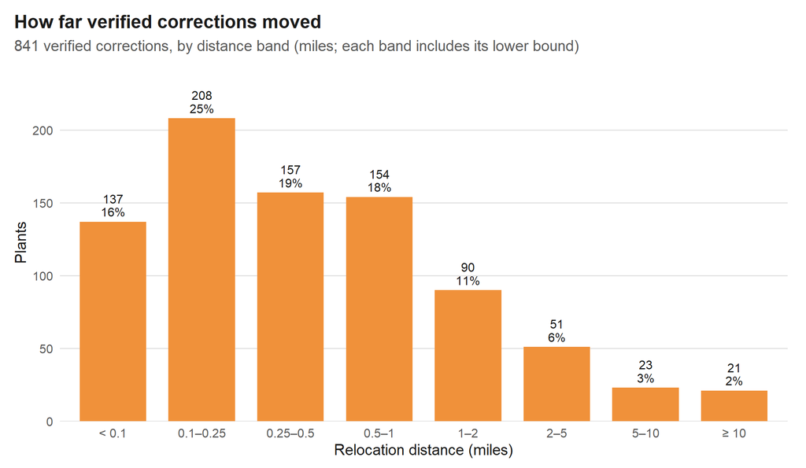

### Fig 3. Distance by how the correction was made

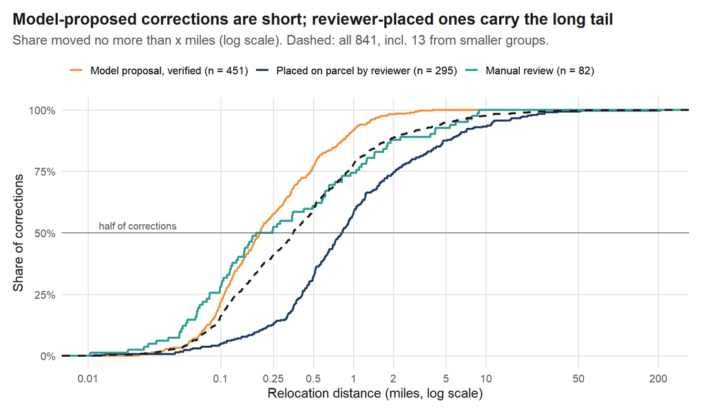

| How corrected | Plants | Median mi | Mean mi | Max mi |
| --- | --- | --- | --- | --- |
| Model proposal, verified | 451 | 0.20 | 0.38 | 3.91 |
| Placed on parcel by reviewer | 295 | 0.81 | 3.26 | 207.04 |
| Manual review | 82 | 0.21 | 1.08 | 8.89 |
| Viewer | 9 | 0.27 | 0.67 | 2.11 |
| Early review | 4 | 0.39 | 12.34 | 48.29 |

### Fig 4. Share of verified plants found wrong, by state

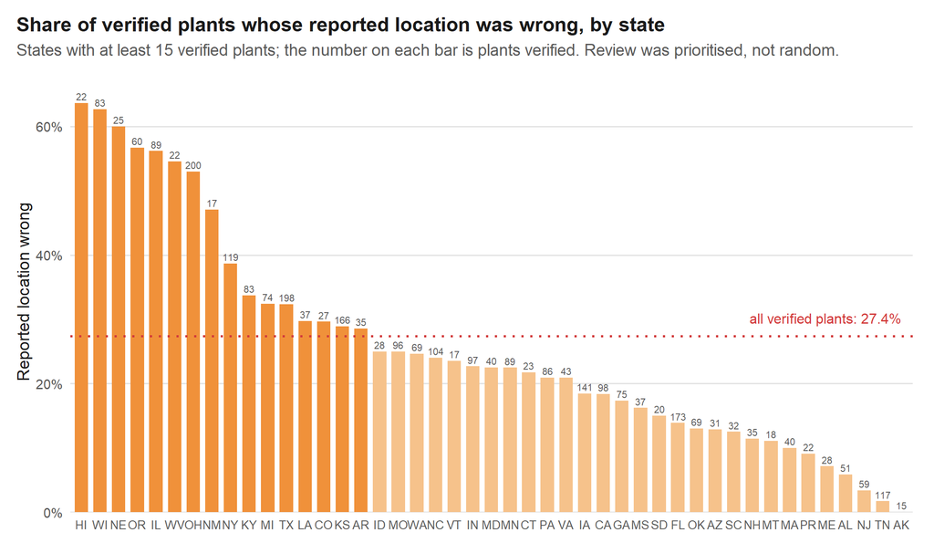

## Where the right location comes from

Sources, as the pipeline names them: **CWNS coordinate** (`cwns_point`, the reported location), **CWNS address geocode** (`cwns_addr`), **ICIS facility coordinate** from FRS for a linked NPDES permit (`icis_fac_frs`), **ICIS address geocode** of that permit (`icis_fac_addr`), and **ICIS permit features** inside the plant: influent structure (`icis_feat_INF`) and internal outfall (`icis_feat_INO`). CWNS and ICIS are separate systems, but the two address geocodes often land on the same point, so they are shown together where they tie.

### Fig 5. Each source’s distance from the verified location

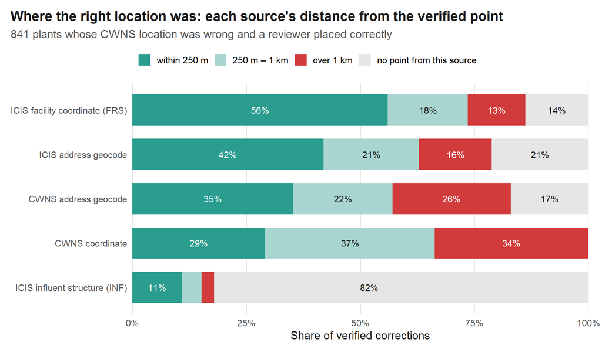

| Source | Has a point | Median distance (m) | Within 250 m, of all plants | Within 250 m, where present |
| --- | --- | --- | --- | --- |
| CWNS coordinate | 100% | 564 | 29% | 29% |
| CWNS address geocode | 83% | 370 | 35% | 43% |
| ICIS facility coordinate (FRS) | 86% | 156 | 56% | 65% |
| ICIS address geocode | 79% | 228 | 42% | 53% |
| ICIS influent structure (INF) | 18% | 175 | 11% | 61% |

The CWNS coordinate is wrong for every plant here by definition (these are the corrected ones). Where it is within 250 m, a reviewer still judged it to be in the wrong place.

### Fig 6. The source closest to the verified location

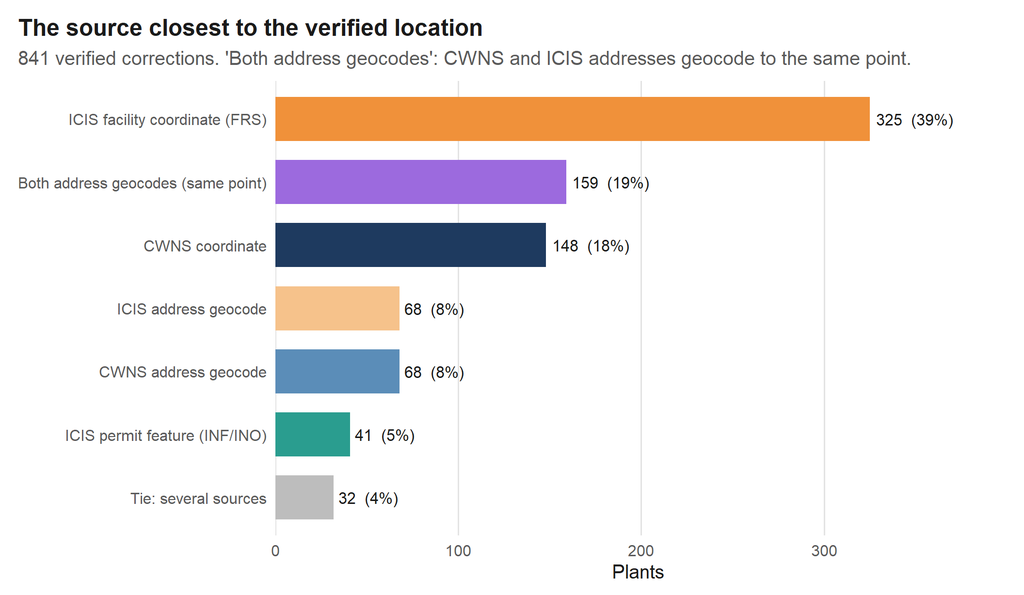

Rolled up: an ICIS source alone was closest for 52%, the CWNS coordinate for 18%, the CWNS address geocode alone for 8%, and the two address geocodes tied for 19%.

### Fig 7. Where the pipeline’s new locations came from

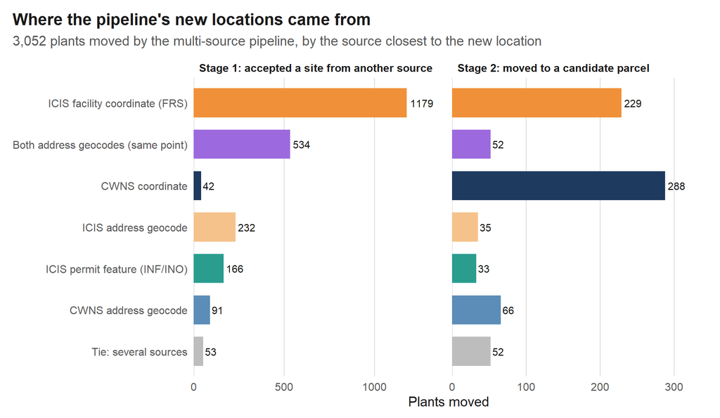

| Stage | Source | Plants | Share |
| --- | --- | --- | --- |
| Stage 1: accepted a site from another source | ICIS facility coordinate (FRS) | 1179 | 51% |
| Stage 1: accepted a site from another source | Both address geocodes (same point) | 534 | 23% |
| Stage 1: accepted a site from another source | ICIS address geocode | 232 | 10% |
| Stage 1: accepted a site from another source | ICIS permit feature (INF/INO) | 166 | 7% |
| Stage 1: accepted a site from another source | CWNS address geocode | 91 | 4% |
| Stage 1: accepted a site from another source | Tie: several sources | 53 | 2% |
| Stage 1: accepted a site from another source | CWNS coordinate | 42 | 2% |
| Stage 2: moved to a candidate parcel | CWNS coordinate | 288 | 38% |
| Stage 2: moved to a candidate parcel | ICIS facility coordinate (FRS) | 229 | 30% |
| Stage 2: moved to a candidate parcel | CWNS address geocode | 66 | 9% |
| Stage 2: moved to a candidate parcel | Both address geocodes (same point) | 52 | 7% |
| Stage 2: moved to a candidate parcel | Tie: several sources | 52 | 7% |
| Stage 2: moved to a candidate parcel | ICIS address geocode | 35 | 5% |
| Stage 2: moved to a candidate parcel | ICIS permit feature (INF/INO) | 33 | 4% |

Stage 1 accepts a site that another source points to, so its new locations come mostly from ICIS. Stage 2 picks a candidate parcel near the reported point, so the CWNS coordinate is often the nearest source: the new parcel is usually a neighbour of the reported one.

## Pipeline results

### Fig 8. Location status of every treatment plant

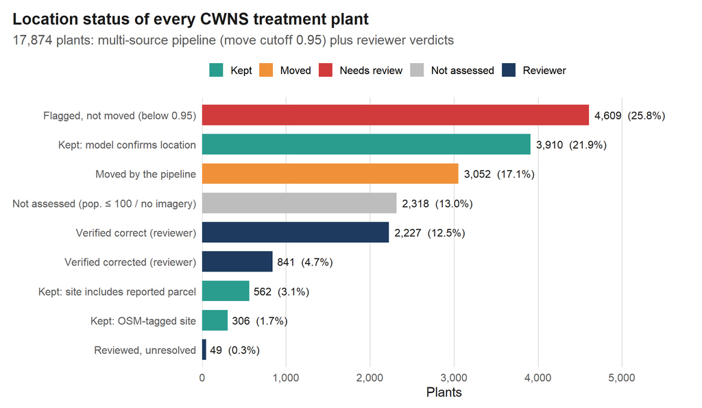

### Fig 9. Pipeline move distances against verified corrections

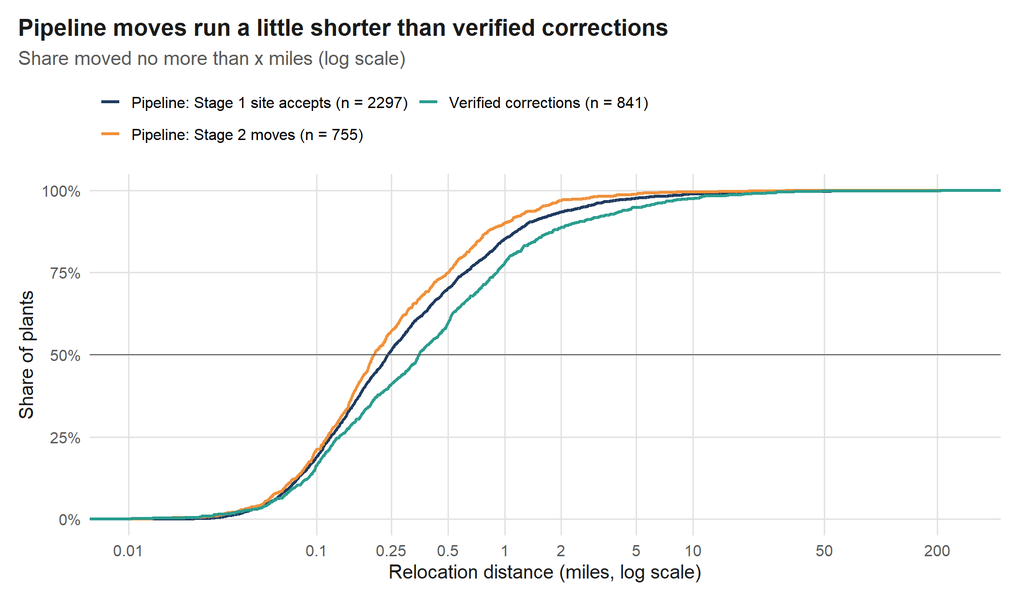

Medians: Stage 2 moves 0.20 mi, Stage 1 site accepts 0.24 mi, verified corrections 0.35 mi. 105 pipeline moves exceed 5 km; they were kept as moves (decision of 6 Nov 2026).

### Fig 10. Frozen holdout: single-seed against multi-source

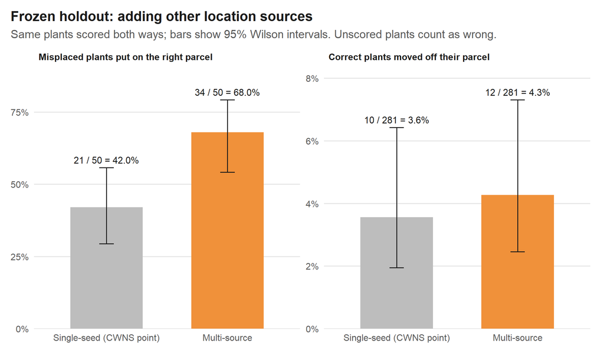

### Fig 11. The same plants, paired

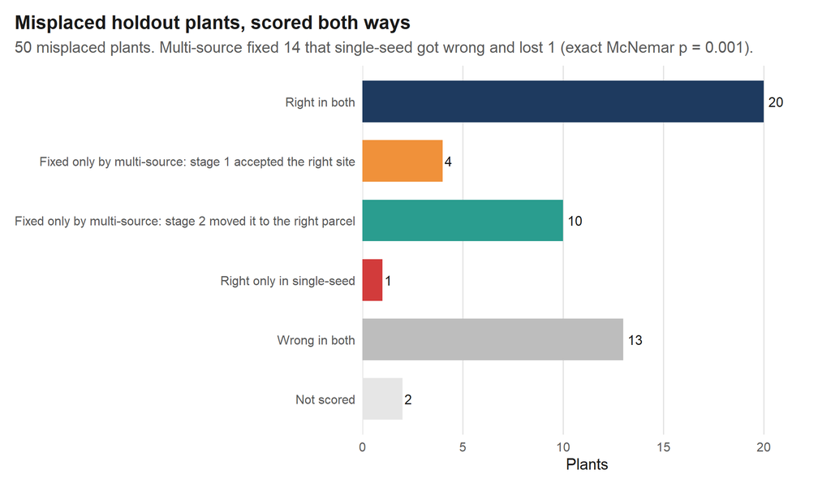

Misplaced plants: outcome in each run (rows single-seed, columns multi-source)

|  | accepted_right | accepted_wrong | flagged_wrong | moved_right | not_scored |
| --- | --- | --- | --- | --- | --- |
| accepted_reported | 2 | 1 | 1 | 1 | 0 |
| flagged_wrong | 2 | 1 | 10 | 9 | 0 |
| moved_right | 13 | 1 | 0 | 7 | 0 |
| not_scored | 0 | 0 | 0 | 0 | 2 |

**Paired result.** On the 50 misplaced plants, multi-source put 14 right that single-seed got wrong and lost 1 (exact McNemar p = 0.001), so the gain is real, not noise. Most of it comes from **Stage 2**, not Stage 1: 10 plants were moved to the right parcel by multi-source’s Stage 2 where single-seed got them wrong, against 4 that multi-source’s Stage 1 accepted outright. Of the 17 plants multi-source’s Stage 1 got right, 13 were already right in single-seed through Stage 2; Stage 1 now reaches them earlier. On the 281 correct plants the runs differ on 10 (4 better, 6 worse, p = 0.75): no detectable change in false moves.